# Statistical Inference Course Project

Zach Olivier

7/23/2017

## Statisical Inference Project

This project contains two sections: 1. Simulation Exercise to solidify basic inference concepts 2. Analysis on the ToothGrowth R dataset

## Simulation Exercise Summary

The goal of part 1 is to examine the exponentail distribution under the Central Limit Theorm. I will simulate the expoential distribution in R for different averages of expoentials over 1,000 simulations.

For reference: The simulation of the expoential distribution in R is rexp(n, lambda), with lambda as the rate parameter. Mean = 1/lambda and Standard Deviation = 1/lambda.

Once the simulation is complete, we will compare the mean, variance, and standard deviation against our simulations. This will put the sample statistics up against the theoretical statistics.

Finally, I will plot the distribution of the simulation to verify the normal distribution.

All analysis is performed in the R code chunk below. Please see documentation for details.

```r
# install needed packages for analysis
library(knitr)
library(ggplot2)
# set up exponetial distribution in R with inputs from question prompt

# exponential sample size
n = 40
# parameter rate for simulation
lambda = 0.2
# number of simulations
sim = 1000
# confidence interval quantile
quant = 1.96
# reproducibility flag - set seed
set.seed(500)

# set up simulation matrix for all samples (matrix = 40 columns (sample size) and 1,000 rows (total simulations)

exp_sim = matrix(rexp(n*sim, rate = lambda), sim)

# calculate averages for the 40 values based on each of the 1,000 simulations

exp_avg = rowMeans(exp_sim)


# compare sample mean, variance, and standard deviation against theoretircal mean, variance and standard deviation

sample_mean_exp = mean(exp_avg) # sample mean
sample_mean_exp
```

```
## [1] 5.010562
```

```r
theor_mean_exp = 1/lambda # theoretical mean
theor_mean_exp
```

```
## [1] 5
```

```r
sample_var_exp = var(exp_avg) # sample variance
sample_var_exp
```

```
## [1] 0.6003934
```

```r
theor_var_exp = (1/lambda) ^2 / (n) #theoretical variance
theor_var_exp
```

```
## [1] 0.625
```

```r
sample_sd_exp = sd(exp_avg) #sample standard deviation
sample_sd_exp
```

```
## [1] 0.7748506
```

```r
theor_sd_exp = 1/(lambda*sqrt(n)) # theoretical standard deviation
theor_sd_exp
```

```
## [1] 0.7905694
```

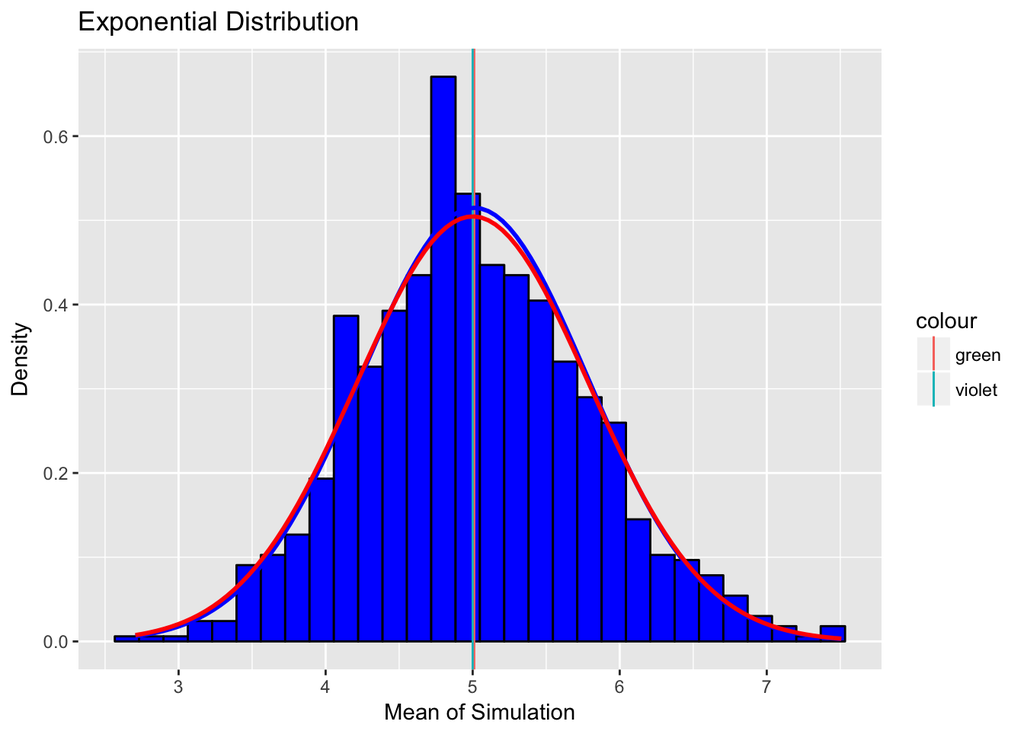

```r
# histogram of the simulation data with sample and theorictical mean and standard deviation overlayed

plot_exp <- data.frame(exp_avg)
e <- ggplot(plot_exp, aes(x =exp_avg))
e <- e + geom_histogram(aes(y=..density..), colour="black",
                        fill = "blue")
e <- e + labs(title = "Exponential Distribution", x = "Mean of Simulation", y = "Density")
e <- e + geom_vline(aes(xintercept = sample_mean_exp, colour = "green"))
e <- e + geom_vline(aes(xintercept = theor_mean_exp, colour = "violet"))
e <- e + stat_function(fun = dnorm, args = list(mean = sample_mean_exp, sd = sample_sd_exp), color = "blue", size = 1.0)
e <- e + stat_function(fun = dnorm, args = list(mean = theor_mean_exp, sd = theor_sd_exp), colour = "red", size = 1.0)
e
```

```r
# create the sample and theoretircal confidence interval to compare

sample_CI = round(mean(exp_avg) + c(-1,1)*quant*sd(exp_avg)/sqrt(n),3)
sample_CI
```

```
## [1] 4.770 5.251
```

```r
theor_CI = theor_mean_exp + c(-1,1) * quant * sqrt(theor_var_exp)/sqrt(n)
theor_CI
```

```
## [1] 4.755 5.245
```

## Simulation Exercise Results

All three of the sample statistics I calculated for the expoential distribution are extremely close to thier theoretical value.

The confidence interval for both sample and theoretical are also extremely close.

Each of these is absolutely expected based on the Central Limit Theorm - the more observations we have, the closer the sample should mirror the theoretical distribution.

## Tooth Growth Analysis Summary

The goal of part 2 is to analyze the ToothGrowth data with basic statistical inference techniques.

All analysis is contained in the R code below. Please see the documentation for details.

```r
# install needed packages for analysis
library(ggplot2)

# load the ToothGrowth data set and prepare for analysis
data("ToothGrowth")

# summary statistic results
summary(ToothGrowth)
```

```
##       len        supp         dose
##  Min.   : 4.20   OJ:30   Min.   :0.500
##  1st Qu.:13.07   VC:30   1st Qu.:0.500
##  Median :19.25           Median :1.000
##  Mean   :18.81           Mean   :1.167
##  3rd Qu.:25.27           3rd Qu.:2.000
##  Max.   :33.90           Max.   :2.000
```

```r
#dataset summary
str(ToothGrowth)
```

```
## 'data.frame':    60 obs. of  3 variables:
##  $ len : num  4.2 11.5 7.3 5.8 6.4 10 11.2 11.2 5.2 7 ...
##  $ supp: Factor w/ 2 levels "OJ","VC": 2 2 2 2 2 2 2 2 2 2 ...
##  $ dose: num  0.5 0.5 0.5 0.5 0.5 0.5 0.5 0.5 0.5 0.5 ...
```

```r
# view the first rows of the data
ToothGrowth[1:10,]
```

```
##     len supp dose
## 1   4.2   VC  0.5
## 2  11.5   VC  0.5
## 3   7.3   VC  0.5
## 4   5.8   VC  0.5
## 5   6.4   VC  0.5
## 6  10.0   VC  0.5
## 7  11.2   VC  0.5
## 8  11.2   VC  0.5
## 9   5.2   VC  0.5
## 10  7.0   VC  0.5
```

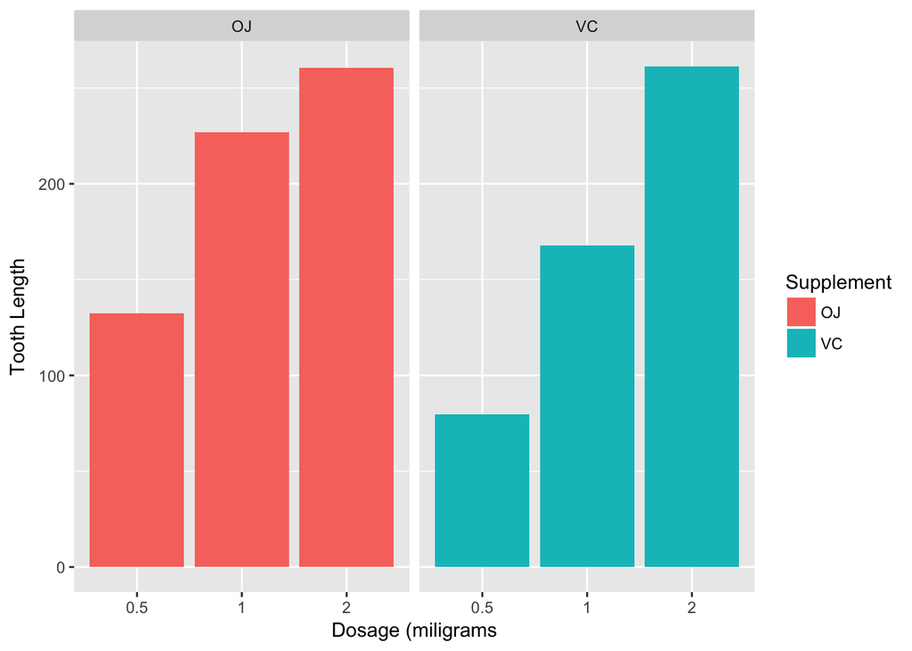

```r
# plot tooth growth by supplement type

ggplot(data=ToothGrowth, aes(x=as.factor(dose), y=len, fill=supp)) +
    geom_bar(stat="identity",) +
    facet_grid(. ~ supp) +
    xlab("Dosage (miligrams") +
    ylab("Tooth Length") +
    guides(fill=guide_legend(title="Supplement"))
```

```r
# use t-test to compare tooth length versus supplement

t.test(len~supp, data = ToothGrowth)
```

```
##
##  Welch Two Sample t-test
##
## data:  len by supp
## t = 1.9153, df = 55.309, p-value = 0.06063
## alternative hypothesis: true difference in means is not equal to 0
## 95 percent confidence interval:
##  -0.1710156  7.5710156
## sample estimates:
## mean in group OJ mean in group VC
##         20.66333         16.96333
```

```r
# repeat t-test for various levels of dosage

t.test(len ~ supp, ToothGrowth[ToothGrowth$dose == .5, ]) # dose at level .5
```

```
##
##  Welch Two Sample t-test
##
## data:  len by supp
## t = 3.1697, df = 14.969, p-value = 0.006359
## alternative hypothesis: true difference in means is not equal to 0
## 95 percent confidence interval:
##  1.719057 8.780943
## sample estimates:
## mean in group OJ mean in group VC
##            13.23             7.98
```

```r
t.test(len ~ supp, ToothGrowth[ToothGrowth$dose == 1, ]) # dose at level 1
```

```
##
##  Welch Two Sample t-test
##
## data:  len by supp
## t = 4.0328, df = 15.358, p-value = 0.001038
## alternative hypothesis: true difference in means is not equal to 0
## 95 percent confidence interval:
##  2.802148 9.057852
## sample estimates:
## mean in group OJ mean in group VC
##            22.70            16.77
```

```r
t.test(len ~ supp, ToothGrowth[ToothGrowth$dose == 2, ]) # dose at level 2
```

```
##
##  Welch Two Sample t-test
##
## data:  len by supp
## t = -0.046136, df = 14.04, p-value = 0.9639
## alternative hypothesis: true difference in means is not equal to 0
## 95 percent confidence interval:
##  -3.79807  3.63807
## sample estimates:
## mean in group OJ mean in group VC
##            26.06            26.14
```